# Golden Section Search Applied to a Lognormal-Type Objective

Sulagna Roy

2026-09-13

# 1 Overview

This document explains a second application of the **golden section search** method, this time minimizing a function built from the **lognormal distribution’s density shape** rather than a simple polynomial. The algorithm itself is identical to the earlier golden-section example — the only change is the objective function `f` and the search interval passed to it. This document focuses the explanation on what makes this new objective different and how that changes the numerical behavior of the search.

# 2 The Objective Function

```r
# Objective function
f <- function(x) {
  -(1/x*sqrt(2*pi))*exp(-0.5*(log(x)*log(x)))
}
```

## 2.1 What this function computes

The (standard) lognormal probability density function is

$$\phi_{\text{LN}}(x) = \frac{1}{x\sqrt{2\pi}} \exp\!\left(-\frac{(\ln
x)^2}{2}\right), \qquad x > 0,$$

## 2.2 Domain consideration

Because of the $1/x$ term and $\ln x$, this function is only defined for $x > 0$; at $x = 0$ it is undefined (division by zero and $\ln 0$). This is why the search below is run starting from `a = 0.01` rather than `a = 0`, keeping the search safely inside the function’s valid domain while still starting very close to zero.

## 2.3 Shape of the function

Unlike the earlier quartic examples, which had two symmetric-looking dips, $-\phi_{\text{LN}}(x)$ has a **single** minimum. The lognormal density rises steeply from 0 near $x=0^+$, peaks at its mode, and then decays slowly toward 0 as $x \to \infty$ — so its negative has a single sharp dip at that same mode and flattens out toward 0 from below as $x$ grows. This means $f$ is unimodal on any interval containing that one dip, exactly the condition golden section search requires.

The mode of a standard lognormal distribution (i.e. $\ln X \sim N(0,1)$) has the closed-form value $x^\* = e^{-\sigma^2} = e^{-1} \approx 0.367879$, which will serve as a useful check against the numerical answer below.

# 3 The Golden Section Search Function

```r
# Golden Section Search
golden_search <- function(f, a, b, tol = 1e-4) {

  tau <- (sqrt(5) - 1) / 2 # 0.618...

  history <- data.frame(
    iter = 0,
    a = a,
    b = b
  )

  x1 <- b - tau * (b - a)
  x2 <- a + tau * (b - a)

  f1 <- f(x1)
  f2 <- f(x2)

  iter <- 0
  while ((b - a) > tol) {
    iter <- iter + 1

    if (f1 > f2) {

      a <- x1
      x1 <- x2
      f1 <- f2

      x2 <- a + tau * (b - a)
      f2 <- f(x2)

    } else {

      b <- x2
      x2 <- x1
      f2 <- f1

      x1 <- b - tau * (b - a)
      f1 <- f(x1)
    }
    history <- rbind(
      history,
      data.frame(iter = iter, a = a, b = b)
    )
  }

  list(
    xmin = (a + b) / 2,
    interval = c(a, b),
    history = history
  )
}
```

## 3.1 Explanation, step by step

This is the same golden section search routine used previously, so the logic is summarized here rather than re-derived from scratch:

**1. Golden ratio conjugate.** `tau <- (sqrt(5) - 1) / 2` sets $\tau \approx 0.618$, the constant satisfying the self-similarity property $\tau^2 = 1-\tau$. This is what allows one interior evaluation point to be recycled at every iteration.

**2. Initial bracketing.** Two interior points are placed inside $[a,b]$:

$$x_1 = b - \tau(b-a), \qquad x_2 = a + \tau(b-a),$$

and `f` — here, the negative lognormal density — is evaluated once at each to get `f1` and `f2`.

**3. Iterative shrinking (`while` loop).** As long as the raw bracket width `b - a` exceeds `tol`:

- **If `f1 > f2`:** the (negative-density) value at the left test point is larger, so under unimodality the mode-minimizer cannot be left of `x1`; the left endpoint advances, `a <- x1`, the old `x2` is recycled as the new `x1`, and a single new `x2` is computed and evaluated.
- **Otherwise:** the right endpoint contracts, `b <- x2`, the old `x1` becomes the new `x2`, and a single new `x1` is computed and evaluated.

Exactly one new call to `f` happens per iteration, and the updated bracket is appended to `history`.

**4. Return value.** Once `b - a <= tol`, the loop stops and the function returns the midpoint `(a + b) / 2` as `xmin`, the tiny final `interval`, and the complete `history` of every bracket along the way.

The only place this objective function’s different shape matters numerically is in *how many* iterations are needed and *where* the interval starts, both of which are visible in the results below.

# 4 Running the Search

```r
# Run Golden Section Search
result <- golden_search(f, a = 0.01, b = 10, tol = 1e-4)

print(result)
```

```
## $xmin
## [1] 0.3678577
##
## $interval
## [1] 0.3678095 0.3679059
##
## $history
##    iter         a          b
## 1     0 0.0100000 10.0000000
## 2     1 0.0100000  6.1841595
## 3     2 0.0100000  3.8258405
## 4     3 0.0100000  2.3683191
## 5     4 0.0100000  1.4675214
## 6     5 0.0100000  0.9107977
## 7     6 0.0100000  0.5667236
```

[output cut: 18 more lines]

## 4.1 Interpreting the result

This time the search interval is $[a,b] = [0.01,\ 10]$ — much wider than the $[1,5]$ interval used for the polynomial examples, because the lognormal density’s interesting behavior (its rise, peak, and long decay) spans a wider range and the domain restriction $x>0$ makes starting near 0 natural.

```r
h <- result$history
h
```

| iter | a | b |
| --- | --- | --- |
| 0 | 0.0100000 | 10.0000000 |
| 1 | 0.0100000 | 6.1841595 |
| 2 | 0.0100000 | 3.8258405 |
| 3 | 0.0100000 | 2.3683191 |
| 4 | 0.0100000 | 1.4675214 |
| 5 | 0.0100000 | 0.9107977 |
| 6 | 0.0100000 | 0.5667236 |
| 7 | 0.2226495 | 0.5667236 |
| 8 | 0.2226495 | 0.4352990 |
| 9 | 0.3038744 | 0.4352990 |

[output cut: 15 more lines]

# 5 Visualizing the Convergence

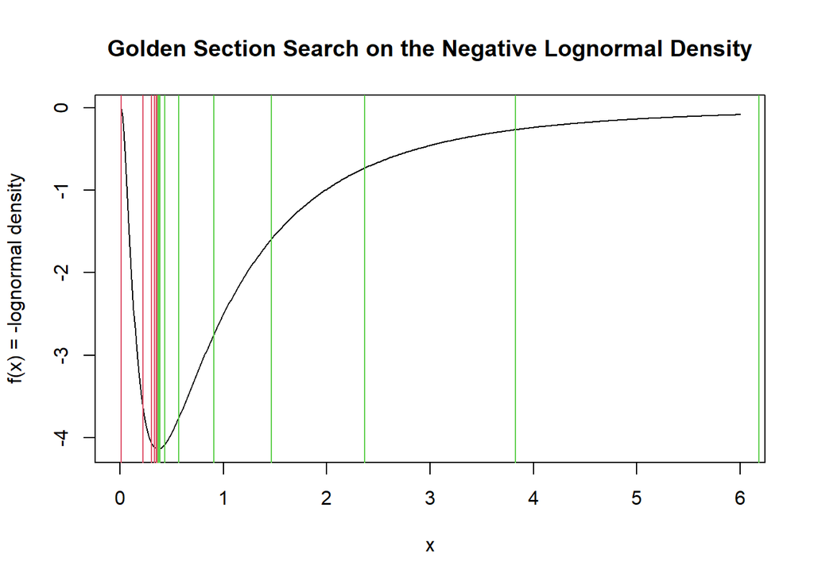

```r
u <- seq(0, 6, length = 500)
plot(u, f(u), type = 'l',
     main = "Golden Section Search on the Negative Lognormal Density",
     xlab = "x", ylab = "f(x) = -lognormal density")

for (i in 1:nrow(h)) {
  abline(v = h[i, 2], col = 2)  # left endpoint a, in red
  abline(v = h[i, 3], col = 3)  # right endpoint b, in green
}
```

## 5.1 Reading the plot

**Note on the plotting range:** the curve is drawn over `u = seq(0, 6, length = 500)`, i.e. only $x \in [0,6]$, even though the search itself ran on the much wider bracket $[0.01, 10]$. This is a minor mismatch in the original script — the plot window happens to still comfortably contain the minimizer near $x \approx 0.368$ and the final, fully-converged bracket lines, but it does **not** show the early iterations’ bracket endpoints that briefly sit outside $[0,6]$ (for example the very first `b = 10`). Those early vertical lines are simply not drawn because they fall outside the visible x-axis range; this does not affect the correctness of the numerical result, only what is visible in this particular plot.

Within the visible window:

# 6 Summary

This example reuses the same golden section search engine as before, demonstrating that the method generalizes immediately to any unimodal objective, not just polynomials: